# Multilayered scGate models: isolating TCD8 cells

# Preliminars

## Background

**scGate** is an open source tool designed for gating specific and uncontaminated cell types in a scRNAseq experiment. We aim to gate cell subtypes at high precision/PPV (i.e achieving high cell type purity) and we don’t care about some loss of true cells (i.e. sensitivity > 90% is ideal). We aim at a reliable tool to purify individual cell types from scRNA-seq data from complex samples (e.g. whole tissue, whole tumor) to enable i) downstream cell type-specific analysis (e.g. reference-atlas projection) and ii) cross-study comparisons/meta-analysis of cell types.

## Multilayer scGate models

A multilayer scGate model could be thought as a logical (AND) concatenation of simple scGate models. The rational behind this, is to mimic the gating process that take place in flow cytometry assays. In those assays, users usually apply some criteria for a first broad gating step, extracting some desidered cellular type, and then apply another new criteria over the output of the first process to refine the search and isolation of a more specific cell type of interest.

In the context of scGate, this translates into an R list of named scGate models that must be passed to *gating.model* parameter of **scGate** function. Please, notice that the order of the objects in the list matters, and it must be from coarse-grained gating models to finer ones. As an example, we will apply the pre-trained two layered model of TCD8 cells

# This demo

In a previous vignette we show the most basic usage of scGate tool (single layer). The reader may refer to these vignettes prior to reading this demon. Here, we are going to show how to take advantage of *scGate* package for filtering-out specific cell subsets by taking advantage of multilayer models. As a case of study we will show how to extract **TCD8 cell** subsets from two recent human single cell datasets: [Jerby-Arnon.2018](https://pubmed.ncbi.nlm.nih.gov/30388455/), [Yost.2019](https://www.nature.com/articles/s41591-019-0522-3)

Notice that the applied T cell model used in this previous vignette works filtering cells in only one step. This means that the model filter T cells from other cell types, excluding at the same time contaminants like doublets, triplets or other cell types by analyzing the match/mismatch with only one set of signatures (provided by the model). When a user is interested in more specific cell types, namely gating TCD8 cells, it is strongly recommended to do the job in an iterative manner. Keeping this into account, scGate tool enables users to build (and use) multi-layer models, like the TCD8 pre-computed model available in scGate_DB. In the first layer, this model gates all pure T cells, and in the second layer the model applies specific TCD8 signatures to pick out these cells in a fine-grained way (i.e. differentiating that cells from TCD4 or NK cells).

# R Environment

Using Renv

```r
if (!requireNamespace("renv")) install.packages("renv")
renv::activate()
renv::restore()
library(dplyr)
library(ggplot2)
library(scGate)
library(patchwork)
```

Or alternatively, manually installing scGate from GitHub

```r
if (!requireNamespace("remotes")) install.packages("remotes")
remotes::install_github("carmonalab/UCell")
remotes::install_github("carmonalab/scGate")
library(scGate)
```

# Get human datasets and preprocess them

## Download data

```r
do_download <- F

ddir <- "input"
if (!file.exists(ddir)) {
    dir.create(ddir)
}

if (do_download) {
    # JerbyArnon - melanoma (GSE115978)
    dataUrl <- "https://drive.switch.ch/index.php/s/GOpKFDP1wtVR3x8/download"
    download.file(dataUrl, paste0(ddir, "/human_Mel_JerbyArnon.rds"))

    # Yost et al. - basal cell carcinoma (GSE123813)
    dataUrl <- "https://drive.switch.ch/index.php/s/dEfDpaWaFeyoAD3/download"
    download.file(dataUrl, paste0(ddir, "/Yost.pretreatment.all.rds"))
}
```

## Basic Seurat unsupervised analysis

Load datasets and permorm dimensionality reduction and unsupervised analysis.

```r
# In this chunck we will a) Load data into a list b) Unfiy author annotations
# in a new column 'cell_type' c) do some basic data preprocessing

seed <- 27182  #pseudo random seed to be used

if (!file.exists("input/human.sets.dimred.rds")) {
    dataset.list <- list()

    a <- readRDS(paste0(ddir, "/human_Mel_JerbyArnon.rds"))
    a$Source <- "Jerby"
    a <- AddMetaData(a, a$cell.types, col.name = "cell_type")
    a <- a %>%
        subset(cell_type != "?")  ## Fiter out 307 unannotated cells
    dataset.list[["Jerby"]] <- a

    a <- readRDS(paste0(ddir, "/Yost.pretreatment.all.rds"))
    a$Source <- "Yost"
    a <- AddMetaData(a, a$cluster, col.name = "cell_type")
    dataset.list[["Yost"]] <- a

    ## Preprocess Dimensionality reduction and unsup. analysis
    set.seed(seed)

    for (set in names(dataset.list)) {
        q <- dataset.list[[set]]

        q <- NormalizeData(q, verbose = FALSE)
        q <- FindVariableFeatures(q, selection.method = "vst", nfeatures = 1000,
            verbose = FALSE)

        q <- ScaleData(q)
        q <- RunPCA(q, features = q@assays$RNA@var.features, ndims.print = 1:5, nfeatures.print = 5,
            verbose = FALSE)
        q <- RunUMAP(q, reduction = "pca", dims = 1:20, seed.use = seed, verbose = FALSE)

        dataset.list[[set]] <- q
    }

    saveRDS(dataset.list, "input/human.sets.dimred.rds")
} else {
    dataset.list <- readRDS("input/human.sets.dimred.rds")
}
```

Visualize the authors’ annotations.

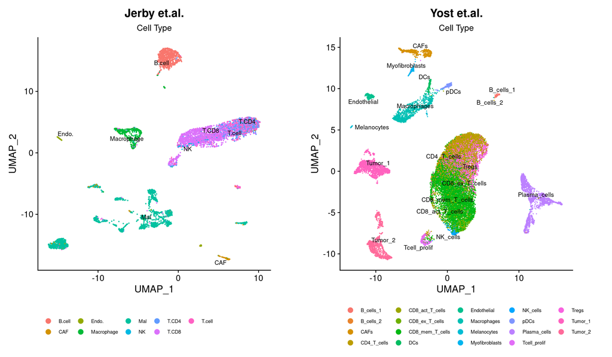

```r
dimplot.Jerby <- DimPlot(object = dataset.list$Jerby, reduction = "umap", group.by = "cell_type",
    label = TRUE, label.size = 3, repel = TRUE) + ggtitle("") + labs(subtitle = "Cell Type") +
    theme(plot.subtitle = element_text(hjust = 0.5)) + theme(legend.position = "bottom") +
    theme(aspect.ratio = 1) + theme(legend.text = element_text(size = 7))

dimplot.Yost <- DimPlot(object = dataset.list$Yost, reduction = "umap", group.by = "cell_type",
    label = TRUE, label.size = 3, repel = TRUE) + ggtitle("") + labs(subtitle = "Cell Type") +
    theme(plot.subtitle = element_text(hjust = 0.5)) + theme(legend.position = "bottom") +
    theme(aspect.ratio = 1) + theme(legend.text = element_text(size = 7))


(dimplot.Jerby + ggtitle("Jerby et.al.")) + (dimplot.Yost + ggtitle("Yost et.al."))
```

# Two layered model: Gating TCD8 cells

A scGate multi-layer model is simply an R list of scGate models (warning: order matters). Models will be executed in an itterative manner

```r
## explore the pre-built two-layer model.
TCD8.model <- scGate_DB$human$CD8.Tcell

# A multilayer model is a list of named scGate models:
class(TCD8.model)
[1] "list"

# see thier names
names(TCD8.model)
[1] "T.cell"    "Tcell_CD8"

# each named element of the list must be a scGate trained model.
class(TCD8.model[["Tcell_CD8"]])
[1] "scGate_Model"
attr(,"package")
[1] "scGate"
```

We only need to apply the two layer pre-trained model of TCD8 cells available in scGate_DB * This may take a few minutes, you can drink a cup of coffee in the meantime.

```r
TCD8.Jerby <- scGate(data = dataset.list$Jerby, gating.model = scGate_DB$human$CD8.Tcell)
TCD8.Yost <- scGate(data = dataset.list$Yost, gating.model = scGate_DB$human$CD8.Tcell)
```

We can use the **is.pure** feature for visualizing or isolation purposes

```r
## dimplots for gated TCD8 cells
dimplot.tcd8.Jerby <- DimPlot(object = TCD8.Jerby, reduction = "umap", group.by = "is.pure",
    label = TRUE, label.size = 3, repel = TRUE) + ggtitle("") + theme(aspect.ratio = 1)

dimplot.tcd8.Yost <- DimPlot(object = TCD8.Yost, reduction = "umap", group.by = "is.pure",
    label = TRUE, label.size = 3, repel = TRUE) + ggtitle("") + theme(aspect.ratio = 1)
```

Pure/Impure classification by Autor’s cell category (barplot)

```r
# Jerby
df <- TCD8.Jerby@meta.data
# reorder labes for visualization purposes.
sorted.levels <- df %>%
    group_by(cell_type) %>%
    dplyr::summarise(Isolated = sum(is.pure == "Pure")) %>%
    arrange(desc(Isolated))  # extract order acording to Nro Pure detected cells
df$cell_type <- factor(df$cell_type, level = sorted.levels$cell_type)

# create the barplot
jerby.bp <- ggplot(df, aes(x = cell_type, fill = is.pure)) + geom_bar() + theme_bw() +
    theme(aspect.ratio = 1) + theme(axis.text.x = element_text(angle = 60, vjust = 0.5,
    hjust = 0.5)) + ggtitle("") + xlab("author's criteria")

# Yost
df <- TCD8.Yost@meta.data
# reorder labes for visualization purposes.
sorted.levels <- df %>%
    group_by(cell_type) %>%
    dplyr::summarise(Isolated = sum(is.pure == "Pure")) %>%
    arrange(desc(Isolated))  # extract order acording to Nro Pure detected cells
df$cell_type <- factor(df$cell_type, level = sorted.levels$cell_type)

# create the barplot
yost.bp <- ggplot(df, aes(x = cell_type, fill = is.pure)) + geom_bar() + theme_bw() +
    theme(aspect.ratio = 1) + theme(axis.text.x = element_text(angle = 60, vjust = 0.5,
    hjust = 0.5)) + ggtitle("") + xlab("author's criteria")

# show plots
barplots <- jerby.bp + yost.bp
```

Show the plots

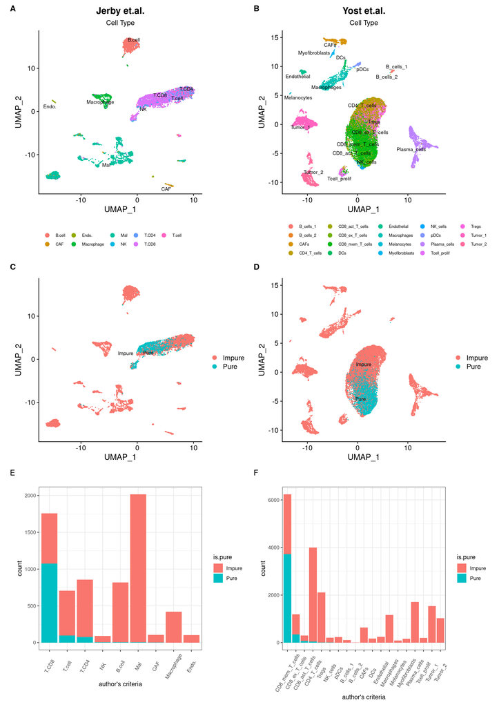

```r
## prepare layout
layout <- "
AB
CD
EG"

## show plots
plt <- patchwork::wrap_plots(A = dimplot.Jerby + ggtitle("Jerby et.al.") + theme(legend.text = element_text(size = 7)),
    B = dimplot.Yost + ggtitle("Yost et.al.") + theme(legend.text = element_text(size = 7)),
    C = dimplot.tcd8.Jerby, D = dimplot.tcd8.Yost, E = jerby.bp, G = yost.bp, design = layout) +
    plot_annotation(tag_levels = "A")

plt
```

# Further reading

The code and the package are available at the *scGate* [GitHub repository](https://github.com/carmonalab/scGate)